# Worm behavior

Riley Skeen-Gaar

April 19, 2016

## Goal of the project

predicting behavior at a particular moment using a set of measured nerve impulses over time

## Description of the dataset

## Models

- Gausian Process
  - individual model for each worm
- Representation using Latent States
- Graphical model structure learning
  - infering covariance structures
- Hidden Markov model

## Questions we want to answer

- What temporal resolution is needed to resolve worm behaviors?
- What has been done in this field previously?
- How can information about one worm inform behavior predictions for another worm?

## Data analysis

First, the data was loaded and represented in the following format. Each observation corresponds to a row. Collumns represent the following: * “time.s.” time of an observation following the begining of the recording. * “x.mm” and “y.mm” represent the position of the center of mass of the worm in mm. * “behavior” is a catagorical variable representing the type of locomotion that the worm is engaged. These catagories are based on “eigenworm” analysis. * “worm” is a catagorical random variable that identifies which individual is being observed in the experiment.

```
## Source: local data frame [6 x 7]
##
##   Time.s.   x.mm.  y.mm. behavior   neuron  signal   worm
##     (dbl)   (dbl)  (dbl)   (fctr)   (fctr)   (dbl) (fctr)
## 1   0.000 -5.4791 1.5114  reverse Neuron.1 0.86033  worm1
## 2   0.165 -5.4771 1.5151  reverse Neuron.1 0.89816  worm1
## 3   0.330 -5.4725 1.5167  reverse Neuron.1 0.83825  worm1
## 4   0.500 -5.4755 1.5171  reverse Neuron.1 0.83344  worm1
## 5   0.666 -5.4709 1.5192     turn Neuron.1 0.89089  worm1
## 6   0.831 -5.4726 1.5178     turn Neuron.1 0.93535  worm1
```

Next the catagorical variables were analysed,

```r
#do the neuron IDs correspond between worms?
#No, based on the paper, the neurons should not correspond
distinct.neurons <-group_by( neuro, worm) %>%
  summarise( total.neurons= n_distinct(neuron))

#what proportion of the signal values are missing?
missing.values <- neuro %>%
  group_by( worm) %>%
  summarize( NaN.observations = sum( is.na( signal)),
             nonNaN.observations= n(),
             percentage.NaN= 100*NaN.observations/ (NaN.observations + nonNaN.observations))

#what percentage of observations consist of each type of behavior?
behave.count <- neuro %>%
  filter( neuron %in% c("Neuron.1")) %>%
  group_by( worm) %>%
  summarize( timepoints= n(),
             percentage.forward= 100* sum( behavior %in% c( "forward")) / timepoints,
             percentage.turn= 100* sum( behavior %in% c( "turn")) / timepoints,
             percentage.pause= 100* sum( behavior %in% c( "pause")) / timepoints,
             percentage.reverse= 100* sum( behavior %in% c( "reverse")) / timepoints)

#change default dplyr width
options( dplyr.width = 300)
#display information on the dataset
bind_cols( distinct.neurons, missing.values[, 2:4], behave.count[, 2:6])
```

```
## Source: local data frame [5 x 10]
##
##      worm total.neurons NaN.observations nonNaN.observations
##    (fctr)         (int)            (int)               (int)
## 1   worm1            56              125              104832
## 2   worm2            77              149              116732
## 3   worm3            68              183               27064
## 4   worm4            57              187               56943
## 5 wormgfp            63              167              129465
##   percentage.NaN timepoints percentage.forward percentage.turn
##            (dbl)      (int)              (dbl)           (dbl)
## 1      0.1190964       1872           83.01282        6.891026
## 2      0.1274801       1516           75.52770        8.377309
## 3      0.6716336        398           70.85427       11.055276
## 4      0.3273236        999           88.98899        5.205205
## 5      0.1288262       2055           79.17275        5.012165
##   percentage.pause percentage.reverse
##              (dbl)              (dbl)
## 1          0.00000          10.096154
## 2         10.55409           5.540897
## 3          0.00000          18.090452
## 4          0.00000           5.805806
## 5          0.00000          15.815085
```

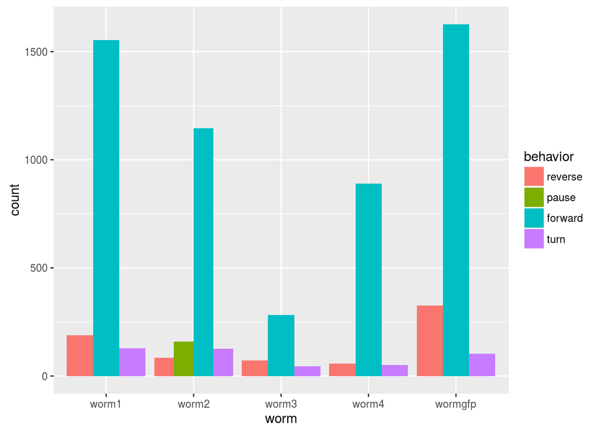

```r
#Plot the behaviour proportions
ggplot( neuro %>% filter( neuron %in% c("Neuron.1")), mapping= aes(x= worm, fill=  behavior)) +
  geom_bar( position = "dodge")
```

```r
#note that some types of behavior are not observed for some worms
```

The values of neuron activity were also analysed

```r
#neuron summary statistics

neuron.summary <- group_by( neuro, worm, neuron ) %>%
  filter( worm != "wormgfp") %>%
  summarise( mean= mean(signal, na.rm= TRUE),
             var= var(signal, na.rm= TRUE),
             median= median(signal, na.rm= TRUE),
             iqr= IQR( signal, na.rm= TRUE))
#are the neuron activities standardized ?
## No
```

The realtionship between mean and variance was also examined.

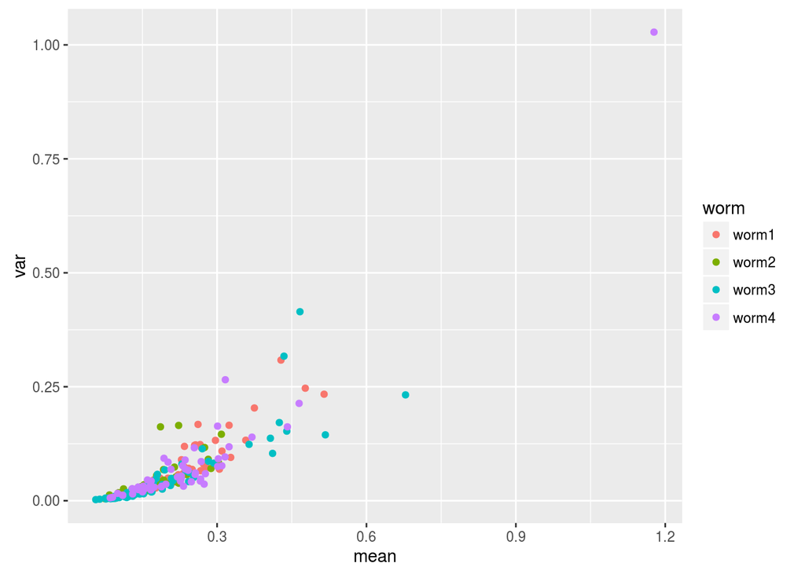

```r
ggplot( neuron.summary,
  mapping = aes( mean, var, colour= worm)) +
  geom_point()
```

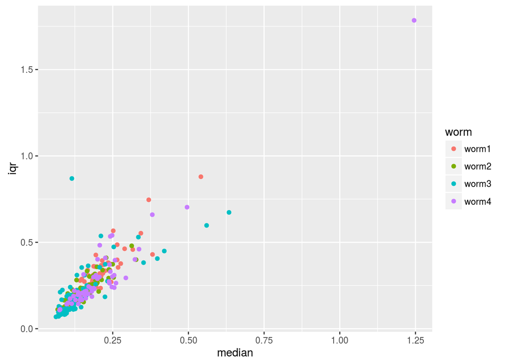

```r
#could the high variance and high mean both be caused by outliers? Try the median and IQR which should be more robust
#this suggests that neurons with high variance tend to have larger variance
ggplot( neuron.summary,
        mapping= aes( median, iqr, colour= worm)) +
  geom_point()
```

Visualizing the time series

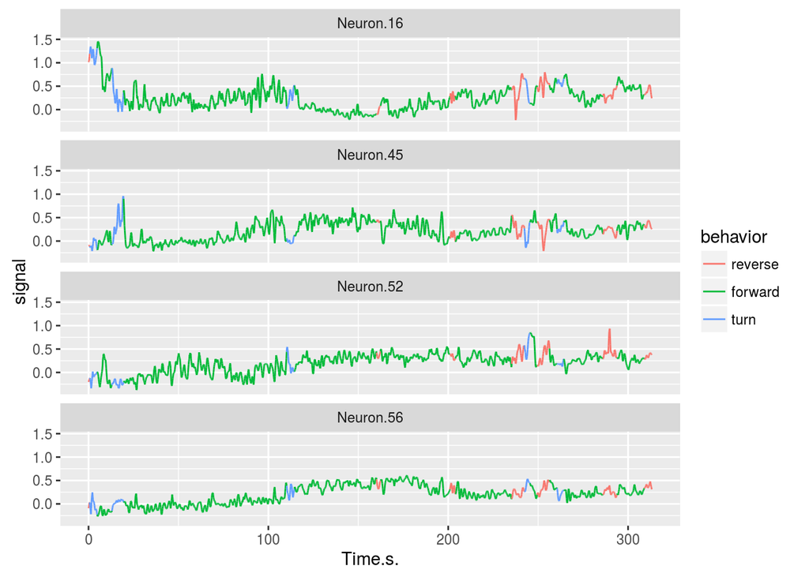

```r
set.seed( 42) #for reprodusable "random" sampling
neuron.to.plot <- paste0("Neuron.", sample.int( distinct.neurons[[1,"total.neurons"]], size= 4)) #randomly select a given number of neurons to plot
#plot the traces of neuron activity for a single worm
ggplot( neuro %>% filter( worm == "worm1", neuron %in% neuron.to.plot),
        mapping= aes( x= Time.s., y= signal)) +
  geom_line(mapping= aes(colour= behavior, group= 1)) +
  facet_wrap( ~ neuron, ncol= 1)
```

```r
ggsave("worm1Traces.eps", width= 10* 1.6, height= 10)
```

## Model Validation

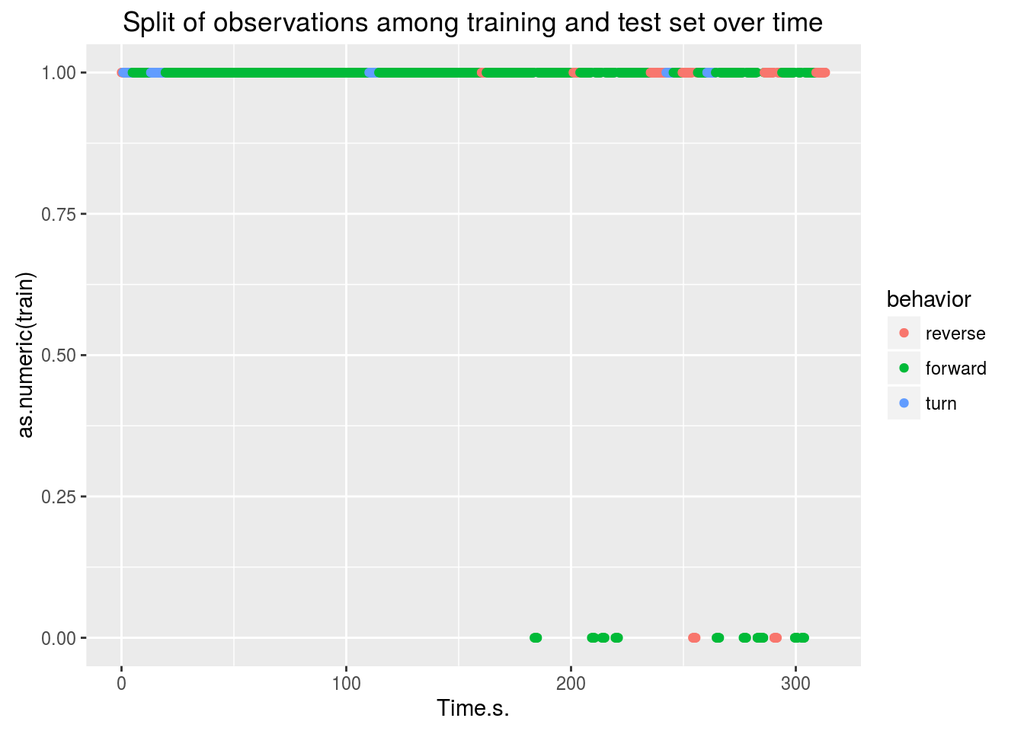

```
## Source: local data frame [3 x 6]
##
##      worm timepoints percentage.forward percentage.turn percentage.pause
##    (fctr)      (int)              (dbl)           (dbl)            (dbl)
## 1   worm1        108           83.33333         0.00000                0
## 2   worm2         36          100.00000         0.00000                0
## 3 wormgfp        291           45.36082        24.05498                0
## Variables not shown: percentage.reverse (dbl)
```

If some neurons have substantially different distributions of activity under different states, then it should be possible to train a hidden markov model to destinguish the states and to account for the overall probabilities of transitions between states

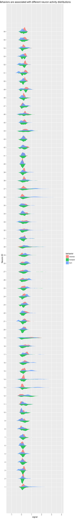

```r
#generate a split violin plot for each neuron using the approach from
# http://stackoverflow.com/questions/35717353/split-violin-plot-with-ggplot2
pdat <- neuro %>% filter( worm == "worm1") %>%
  group_by( behavior, neuron) %>%
  do( data.frame( loc= density(.$signal, na.rm= TRUE)$x,
                  dens= density(.$signal, na.rm= TRUE)$y))

# flip offset density for forward behavior
pdat$dens <- ifelse( pdat$behavior == "forward", pdat$dens * -1, pdat$dens)
pdat <- pdat %>%
  #create numeric indeces for each neuron
  mutate( neuron.number = as.numeric( gsub( pattern= "[^0-9]", replacement="", x= as.character(neuron))),
          #shift each neuron according to its number
          dens.shift= dens + 7*(neuron.number - 1))

ggplot( pdat, mapping= aes( x= loc, y= dens.shift, fill= behavior, group= interaction( behavior, neuron))) +
  geom_polygon(alpha=0.8) +
  scale_y_continuous(breaks = seq(0,7*(max(pdat$neuron.number)-1), by=7), labels= as.character(1:max(pdat$neuron.number))) +
labs( x= "signal", y="Neuron ID", title= "Behaviors are associated with different neuron activity distributions")
```

## Hidden Markov Model

A generative model that can potentially be simple to estimate. For example, let the activity of each neuron be multivariate normal and let the staes of the model be forward, backward, turn, and pause. Following the approach of MLAPP, the transition matrix and multinomial distribution of initial states can be estimated using the observed proportions in the dataset.

```r
#split the data into X Y format
dim( filter( train, worm == "worm1", neuron== "Neuron.1"))
```

```
## [1] 1764   12
```

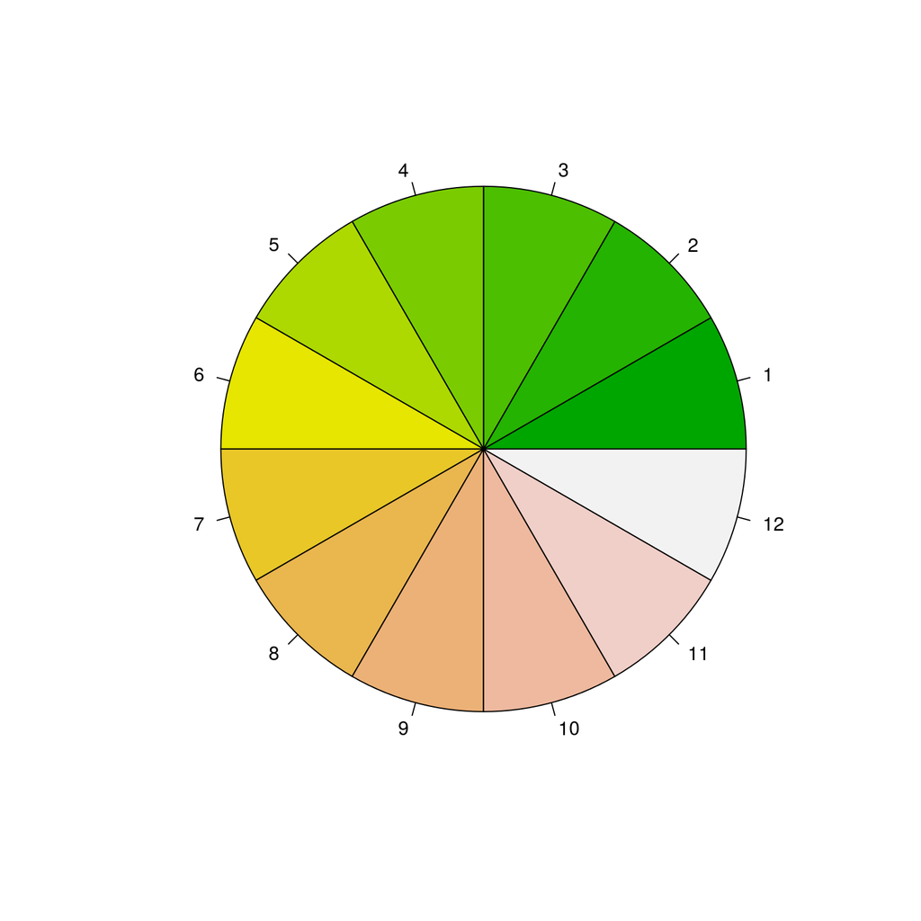

```r
train.wide <- train %>% group_by( segment, worm) %>%
  spread( neuron, signal)

#calculate couts of each behavior, these are the multinomial proportions for the initial state

#iterate through each of the observations, count the number of each type of transition
#normalize rows of the count matrix to obtain the transition matrix
#estimate the mean of the MVN using the sample mean
#use the sample covariance matrix as an estimator of the covariance matrix of each behavior

#list all worms and behaviors to later label neurons
behaviors <- unique( as.character( train.wide$behavior))
worms <- unique( as.character( train.wide$worm))
myWorm <- "worm1"
myBeh <- "reverse"
#for each worm and each behavior, calculate the covariance matrix of the neurons
worm.covs <- lapply( worms, function( myWorm){
  covs.myWorm <- lapply( behaviors, function( myBeh) {
    #get total number of neurons for this worm
    total.neurons <- distinct.neurons$total.neurons[ which( as.character(distinct.neurons$worm) == myWorm)]
    beh.mat <- train.wide %>%
      ungroup() %>%
      filter( as.character(behavior) == myBeh,
              as.character( worm)== myWorm) %>%
      select( one_of( paste0("Neuron.", 1:total.neurons))) %>%
      as.data.frame()
    #return an empty vector for behaviors with no observations
    if( dim(beh.mat)[1] == 0)
      return( c())
    #drop missing values
    #beh.mat <- beh.mat[ !is.na( rowSums( beh.mat, na.rm= FALSE)), ]
    cov.mat <-cov(beh.mat, use="pairwise.complete.obs")
    cov.mat
  })
  names( covs.myWorm) <- behaviors
  covs.myWorm
})
names( worm.covs) <- worms

#color scale
pie(rep(1, 12), col = terrain.colors(12))
```

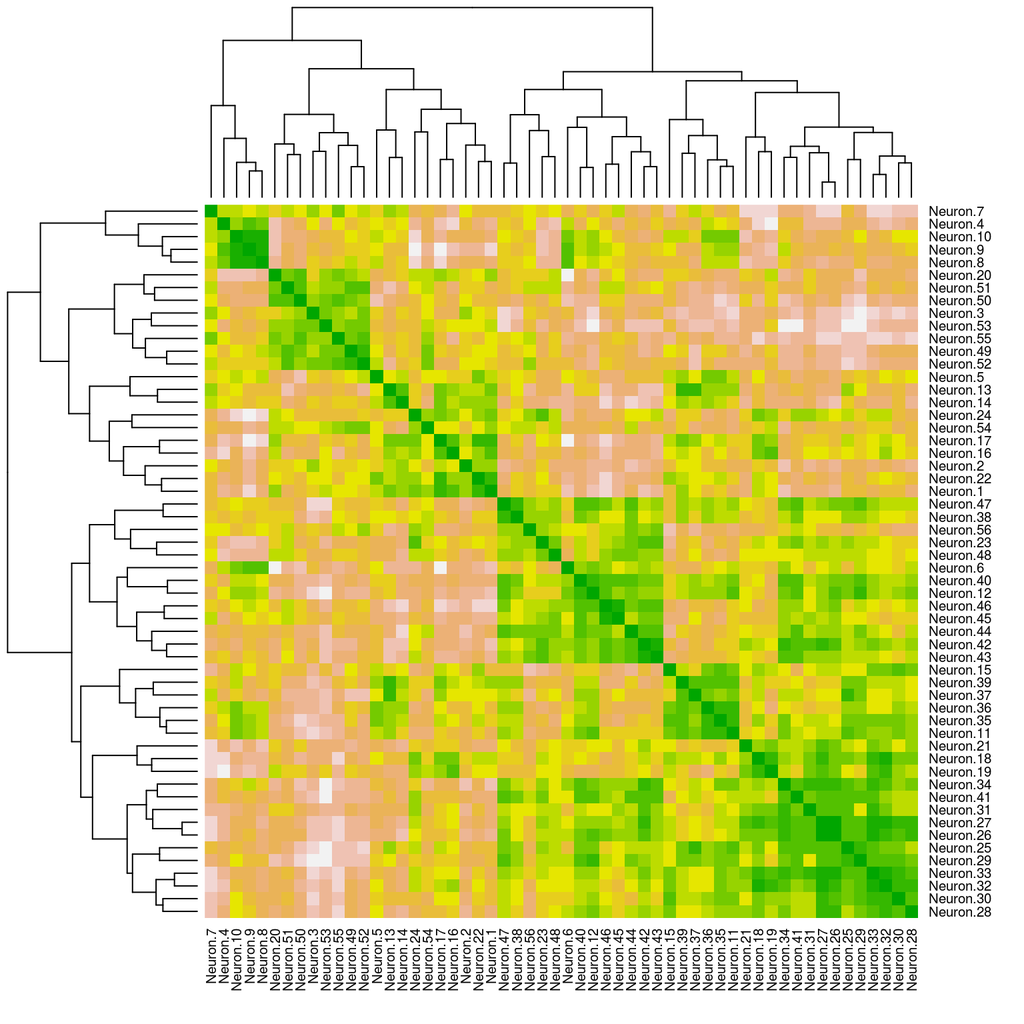

```r
#reverse
heatmap(  1-cov2cor( worm.covs[[1]][[1]]), symm= TRUE, col = terrain.colors(16))
```

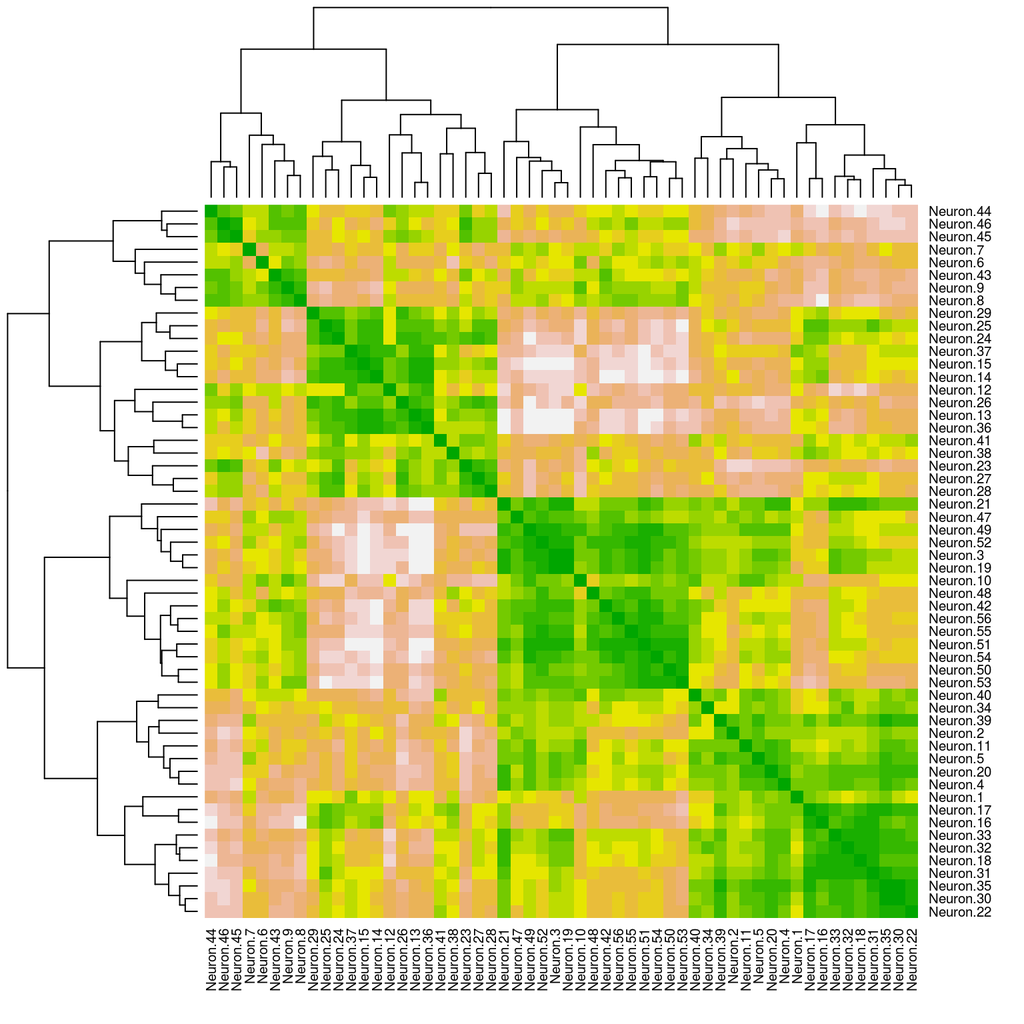

```r
#turn
heatmap(  1-cov2cor( worm.covs[[1]][[2]]), symm= TRUE, col = terrain.colors(16))
```

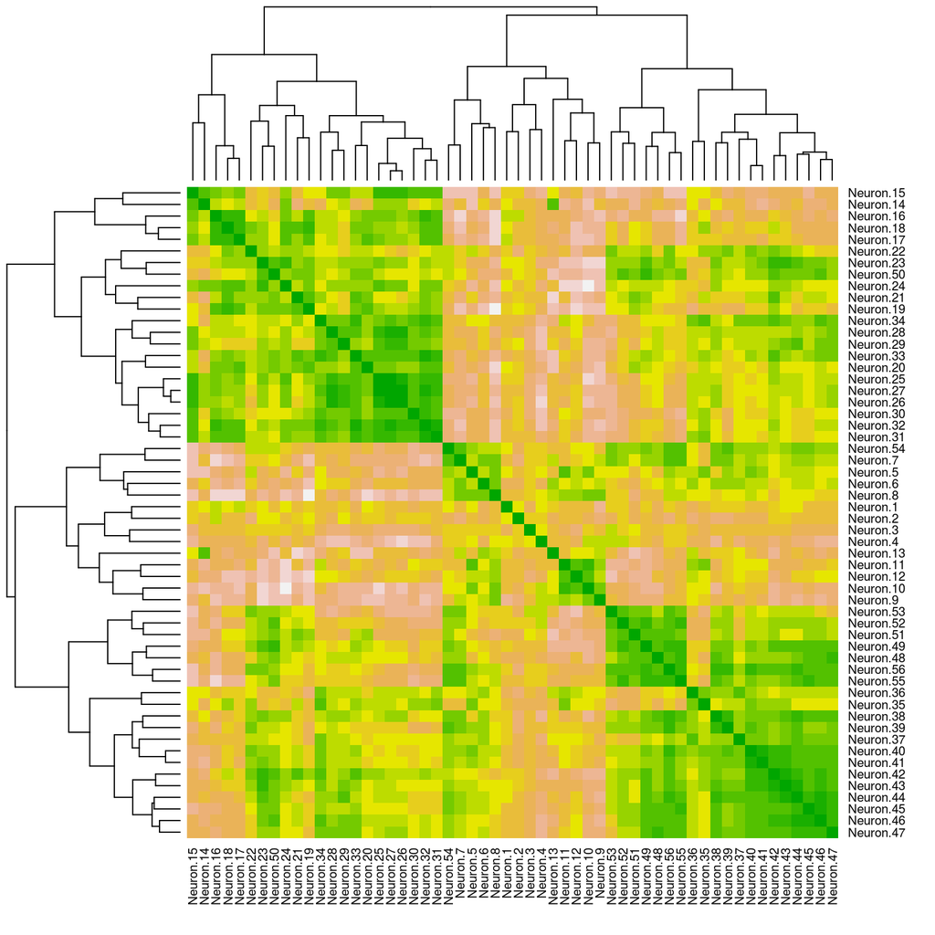

```r
#forward
heatmap(  1-cov2cor( worm.covs[[1]][[3]]), symm= TRUE, col = terrain.colors(16))
```

```r
#pause
#XXX this shouldn't be the case if worm1 doesn't ever pause
#heatmap(  1-cov2cor( worm.covs[[1]][[4]]), symm= TRUE, col = terrain.colors(16))
```

## Conditional Random Field

- Conditional Random Fields
- Attributes: Descriminative